# ECONOMETRIC AND STATISTICAL LEARNING MODELS FOR CANCER DETECTION WITH DATA FROM COMPUTATIONAL GENOMICS

# Author: Pablo Campos Viana

## Chapter 3 - Models and results

We begin by loading the required packages.

```r
library(TCGA2STAT)
library(plyr)
library(dplyr)
library(parallel)
library(doParallel)
library(caret)
library(kernlab)
library(Rtsne)
library(glmnet)
library(ggfortify)
options(warn=-1)
```

We download and load the data from the TCGA portal using the *getTCGA* function from the **TCGA2STAT** package. We assign labels to each type of cancer and we merge both of them in a single dataframe. We can count how many cases of each cancer there are in the data.

```r
cesc <- getTCGA(disease="CESC", data.type="RNASeq2", clinical = F)
```

```
RNASeqV2 data will be imported! This may take some time!
tar: Failed to set default locale
tar: Failed to set default locale
20501 genes have been imported!
```

```r
ucec <- getTCGA(disease="UCEC", data.type="RNASeq2", clinical = F)
```

```
RNASeqV2 data will be imported! This may take some time!
tar: Failed to set default locale
tar: Failed to set default locale
20501 genes have been imported!
```

```r
df.cesc <- as.data.frame(t(cesc$dat)) %>% mutate(label = "CESC")
df.ucec <- as.data.frame(t(ucec$dat)) %>% mutate(label = "UCEC")
df <- rbind(df.cesc, df.ucec)
rm(df.cesc,df.ucec)
table(df$label)
```

```
CESC UCEC
 309  201
```

We can use all the cores from our computer to perform the grid search and cross validation in parallel.

```r
registerDoParallel(cores=detectCores())
getDoParWorkers()
```

```
[1] 4
```

We split the data into train and test datasets. We assign 75% of the data to train dataset.

```r
set.seed(123)
inTrain <- createDataPartition(y = df$label, p = .75, list = FALSE)
train <- df[inTrain,]
test <- df[-inTrain,]
```

We can see how many cases lies in each of these partitions.

```r
print(train %>% nrow)
```

```
[1] 383
```

```r
print(test %>% nrow)
```

```
[1] 127
```

# 3.1 - Traditional approach

We define a function to select some top variables based on higher standar deviations, filter highly correlated variables and then perform the *stepAIC* routine from the **MASS** package in order to carry out stepwise logistic regression with backward elimiation.

```r
fitting_stepwise<-function(n_vars,direction) {

  sds <- apply((train %>% select(-label)), 2, sd) %>% sort(decreasing=T)
  topvars <- sds %>% head(n_vars) %>% names
  to_remove <- train %>%
  select(one_of(topvars)) %>%
  cor(.) %>%
  findCorrelation(.,cutoff = .70, verbose=F, names=T)
  topvars <- setdiff(topvars,to_remove)

  library(MASS)

  x <- dplyr::select(train, one_of(topvars))
  pp <- preProcess(x, method=c("center","scale"))
  xaux <- predict(pp,x)
  yaux <- as.numeric(if_else(train$label == "CESC",1,0))
  dfaux <- cbind(xaux,yaux)
  rm(xaux,yaux)

  model <- glm(as.numeric(yaux) ~ ., data = dfaux, family=binomial)
  sw_model <- stepAIC(model, direction = direction)

  xt <- dplyr::select(test,one_of(topvars))
  xauxt <- predict(pp,xt)
  yauxt <- as.numeric(if_else(test$label == "CESC",1,0))
  dfauxt <- cbind(xauxt,yauxt)
  rm(xauxt,yauxt)

  preds_model_train <- predict.glm(sw_model,newdata=dfaux,type="response")
  preds_model_train <- if_else(preds_model_train >= 0.5, "CESC", "UCEC")
  cm <- confusionMatrix(preds_model_train,train$label)
  print(cm)

  preds_model <- predict.glm(sw_model,newdata=dfauxt,type="response")
  preds_model <- if_else(preds_model >= 0.5, "CESC", "UCEC")

  cm <- confusionMatrix(preds_model,test$label)
  print(cm)
  print(summary(sw_model))
  detach("package:MASS")
  return(sw_model)
}
```

And now we can use our previously defined function.

```r
bw_model <- fitting_stepwise(50,"backward")
```

```
glm.fit: algorithm did not convergeglm.fit: fitted probabilities numerically 0 or 1 occurred
```

```
Start:  AIC=2026.36
as.numeric(yaux) ~ KRT14 + KRT17 + ADAM6 + KRT13 + KRT6A + S100A8 +
    H19 + WFDC2 + GAPDH + KRT16 + CD74 + CD24 + FTH1 + FTL +
    ACTB + EEF1A1 + RPL19 + HSPB1 + TMSB10 + B2M + CLU + S100A6 +
    SLPI + KRT19 + KRT15 + RPL8 + ERBB2 + TMSL3 + KRT8 + ACTG1 +
    HP + VIM + `HLA-A` + NDRG1 + TAGLN + COL1A2 + LCN2 + FBLN1 +
    RPLP1
```

[output not shown]

```
          Df Deviance     AIC
- KRT19    1    55.81  133.81
- S100A8   1    55.87  133.87
- TAGLN    1    56.64  134.64
- CLU      1    57.95  135.95
- NDRG1    1    59.12  137.12
- HP       1    59.26  137.26
- H19      1    59.53  137.53
- CD24     1    60.20  138.20
- `HLA-A`  1    60.39  138.39
- KRT13    1    60.87  138.87
- COL1A2   1    61.06  139.06
- KRT14    1    61.71  139.71
- WFDC2    1    62.05  140.05
- RPLP1    1    62.25  140.25
- KRT8     1    64.28  142.28
- FBLN1    1    64.93  142.93
- ACTG1    1    65.68  143.68
- B2M      1    67.58  145.58
- GAPDH    1    67.84  145.84
- KRT15    1    67.87  145.87
- HSPB1    1    68.06  146.06
- CD74     1    72.40  150.40
- S100A6   1    72.98  150.98
- KRT17    1    74.74  152.74
- EEF1A1   1    79.46  157.46
- TMSB10   1    80.19  158.19
- VIM      1  1441.75 1519.75
- KRT6A    1  1513.83 1591.83
- KRT16    1  1658.01 1736.01
- ACTB     1  1658.01 1736.01
- LCN2     1  1658.01 1736.01
- RPL19    1  1802.18 1880.18
- SLPI     1  1946.36 2024.36
- TMSL3    1  1946.36 2024.36
<none>        1946.36 2026.36
- FTL      1  2090.53 2168.53
- RPL8     1  2090.53 2168.53
- FTH1     1  2162.62 2240.62
- ADAM6    1  2450.97 2528.97
- ERBB2    1  2739.32 2817.32
```

```
glm.fit: fitted probabilities numerically 0 or 1 occurred
```

```
Step:  AIC=133.81
as.numeric(yaux) ~ KRT14 + KRT17 + ADAM6 + KRT13 + KRT6A + S100A8 +
    H19 + WFDC2 + GAPDH + KRT16 + CD74 + CD24 + FTH1 + FTL +
    ACTB + EEF1A1 + RPL19 + HSPB1 + TMSB10 + B2M + CLU + S100A6 +
    SLPI + KRT15 + RPL8 + ERBB2 + TMSL3 + KRT8 + ACTG1 + HP +
    VIM + `HLA-A` + NDRG1 + TAGLN + COL1A2 + LCN2 + FBLN1 + RPLP1
```

[output not shown]

```
          Df Deviance     AIC
- LCN2     1    55.90  131.90
- S100A8   1    56.04  132.04
- ACTB     1    56.28  132.28
<none>          55.81  133.81
- CLU      1    58.01  134.01
- HP       1    59.27  135.27
- CD24     1    60.54  136.54
- KRT13    1    61.10  137.10
- WFDC2    1    62.05  138.05
- KRT14    1    62.13  138.13
- RPLP1    1    62.30  138.30
- FTH1     1    63.87  139.87
- FBLN1    1    64.94  140.94
- ACTG1    1    65.72  141.72
- B2M      1    67.69  143.69
- GAPDH    1    67.85  143.85
- KRT15    1    68.23  144.23
- HSPB1    1    68.29  144.29
- CD74     1    72.40  148.40
- S100A6   1    74.02  150.02
- KRT17    1    75.81  151.81
- EEF1A1   1    79.52  155.52
- KRT8     1  1441.75 1517.75
- VIM      1  1513.83 1589.83
- `HLA-A`  1  1585.92 1661.92
- ADAM6    1  1730.10 1806.10
- H19      1  1730.10 1806.10
- KRT16    1  1730.10 1806.10
- NDRG1    1  1730.10 1806.10
- TAGLN    1  1730.10 1806.10
- RPL19    1  1802.18 1878.18
- RPL8     1  1802.18 1878.18
- COL1A2   1  1802.18 1878.18
- TMSL3    1  1874.27 1950.27
- KRT6A    1  1946.36 2022.36
- FTL      1  1946.36 2022.36
- ERBB2    1  2162.62 2238.62
- TMSB10   1  2306.79 2382.79
- SLPI     1  2306.79 2382.79
```

```
glm.fit: fitted probabilities numerically 0 or 1 occurred
```

```
Step:  AIC=131.9
as.numeric(yaux) ~ KRT14 + KRT17 + ADAM6 + KRT13 + KRT6A + S100A8 +
    H19 + WFDC2 + GAPDH + KRT16 + CD74 + CD24 + FTH1 + FTL +
    ACTB + EEF1A1 + RPL19 + HSPB1 + TMSB10 + B2M + CLU + S100A6 +
    SLPI + KRT15 + RPL8 + ERBB2 + TMSL3 + KRT8 + ACTG1 + HP +
    VIM + `HLA-A` + NDRG1 + TAGLN + COL1A2 + FBLN1 + RPLP1
```

[output not shown]

```
          Df Deviance     AIC
- ERBB2    1    55.92  129.92
- RPL19    1    55.93  129.93
- TMSL3    1    55.97  129.97
- S100A8   1    56.04  130.04
- ACTB     1    56.39  130.39
- TAGLN    1    56.77  130.77
- ADAM6    1    56.98  130.98
<none>          55.90  131.90
- CLU      1    58.01  132.01
- KRT16    1    58.77  132.77
- HP       1    59.45  133.45
- H19      1    59.60  133.60
- `HLA-A`  1    60.42  134.42
- CD24     1    60.55  134.55
- KRT13    1    61.17  135.17
- KRT14    1    62.14  136.14
- WFDC2    1    62.15  136.15
- RPLP1    1    62.30  136.30
- FTH1     1    63.87  137.87
- FBLN1    1    64.95  138.95
- ACTG1    1    65.87  139.87
- KRT8     1    67.42  141.42
- B2M      1    67.69  141.69
- GAPDH    1    67.87  141.87
- KRT15    1    68.31  142.31
- HSPB1    1    68.57  142.57
- CD74     1    72.54  146.54
- S100A6   1    74.50  148.50
- KRT17    1    75.99  149.99
- EEF1A1   1    79.62  153.62
- TMSB10   1    81.73  155.73
- VIM      1  1658.01 1732.01
- SLPI     1  1730.10 1804.10
- KRT6A    1  1802.18 1876.18
- NDRG1    1  1802.18 1876.18
- RPL8     1  1874.27 1948.27
- COL1A2   1  1946.36 2020.36
- FTL      1  2667.23 2741.23
```

```
glm.fit: fitted probabilities numerically 0 or 1 occurred
```

```
Step:  AIC=129.92
as.numeric(yaux) ~ KRT14 + KRT17 + ADAM6 + KRT13 + KRT6A + S100A8 +
    H19 + WFDC2 + GAPDH + KRT16 + CD74 + CD24 + FTH1 + FTL +
    ACTB + EEF1A1 + RPL19 + HSPB1 + TMSB10 + B2M + CLU + S100A6 +
    SLPI + KRT15 + RPL8 + TMSL3 + KRT8 + ACTG1 + HP + VIM + `HLA-A` +
    NDRG1 + TAGLN + COL1A2 + FBLN1 + RPLP1
```

[output not shown]

```
          Df Deviance     AIC
- RPL19    1    55.98  127.98
- S100A8   1    56.05  128.05
- ACTB     1    56.39  128.39
- TAGLN    1    56.77  128.77
- ADAM6    1    57.01  129.01
<none>          55.92  129.92
- CLU      1    58.10  130.10
- H19      1    59.63  131.63
- HP       1    59.67  131.67
- `HLA-A`  1    60.53  132.53
- CD24     1    60.60  132.60
- KRT13    1    61.45  133.45
- KRT14    1    62.21  134.21
- RPLP1    1    62.31  134.31
- WFDC2    1    62.54  134.54
- FTH1     1    64.00  136.00
- FBLN1    1    64.95  136.95
- ACTG1    1    66.70  138.70
- KRT8     1    67.42  139.42
- B2M      1    67.77  139.77
- GAPDH    1    67.87  139.87
- KRT15    1    68.68  140.68
- HSPB1    1    69.07  141.07
- CD74     1    72.73  144.73
- S100A6   1    75.69  147.69
- KRT17    1    76.12  148.12
- EEF1A1   1    79.65  151.65
- FTL      1  1730.10 1802.10
- TMSB10   1  1874.27 1946.27
- SLPI     1  1946.36 2018.36
- KRT6A    1  2090.53 2162.53
- RPL8     1  2162.62 2234.62
- NDRG1    1  2162.62 2234.62
- VIM      1  2306.79 2378.79
- KRT16    1  2523.06 2595.06
- COL1A2   1  2595.14 2667.14
- TMSL3    1  2739.32 2811.32
```

```
glm.fit: fitted probabilities numerically 0 or 1 occurred
```

```
Step:  AIC=127.98
as.numeric(yaux) ~ KRT14 + KRT17 + ADAM6 + KRT13 + KRT6A + S100A8 +
    H19 + WFDC2 + GAPDH + KRT16 + CD74 + CD24 + FTH1 + FTL +
    ACTB + EEF1A1 + HSPB1 + TMSB10 + B2M + CLU + S100A6 + SLPI +
    KRT15 + RPL8 + TMSL3 + KRT8 + ACTG1 + HP + VIM + `HLA-A` +
    NDRG1 + TAGLN + COL1A2 + FBLN1 + RPLP1
```

[output not shown]

```
          Df Deviance     AIC
- S100A8   1    56.13  126.13
- ADAM6    1    57.15  127.15
<none>          55.98  127.98
- CLU      1    58.31  128.31
- KRT16    1    58.85  128.85
- HP       1    59.80  129.80
- H19      1    59.81  129.81
- CD24     1    61.24  131.24
- COL1A2   1    61.62  131.62
- KRT13    1    61.65  131.65
- RPLP1    1    62.32  132.32
- WFDC2    1    62.55  132.55
- KRT14    1    62.67  132.67
- FTH1     1    64.05  134.05
- FBLN1    1    65.08  135.08
- ACTG1    1    66.70  136.70
- KRT8     1    67.42  137.42
- GAPDH    1    67.88  137.88
- B2M      1    68.58  138.58
- KRT15    1    69.16  139.16
- HSPB1    1    69.45  139.45
- CD74     1    73.17  143.17
- S100A6   1    75.90  145.90
- KRT17    1    76.77  146.77
- EEF1A1   1    80.58  150.58
- TMSB10   1    82.04  152.04
- RPL8     1  1513.83 1583.83
- NDRG1    1  1585.92 1655.92
- VIM      1  1730.10 1800.10
- `HLA-A`  1  1730.10 1800.10
- TMSL3    1  1802.18 1872.18
- TAGLN    1  2018.44 2088.44
- SLPI     1  2162.62 2232.62
- KRT6A    1  2234.71 2304.71
- ACTB     1  2306.79 2376.79
- FTL      1  2595.14 2665.14
```

```
glm.fit: fitted probabilities numerically 0 or 1 occurred
```

```
Step:  AIC=126.13
as.numeric(yaux) ~ KRT14 + KRT17 + ADAM6 + KRT13 + KRT6A + H19 +
    WFDC2 + GAPDH + KRT16 + CD74 + CD24 + FTH1 + FTL + ACTB +
    EEF1A1 + HSPB1 + TMSB10 + B2M + CLU + S100A6 + SLPI + KRT15 +
    RPL8 + TMSL3 + KRT8 + ACTG1 + HP + VIM + `HLA-A` + NDRG1 +
    TAGLN + COL1A2 + FBLN1 + RPLP1
```

[output not shown]

```
          Df Deviance    AIC
- FTL      1   56.156 124.16
- TMSL3    1   56.173 124.17
- RPL8     1   56.176 124.18
- KRT6A    1   56.817 124.82
- ACTB     1   56.830 124.83
- TAGLN    1   57.066 125.07
- ADAM6    1   57.506 125.51
- SLPI     1   58.046 126.05
<none>         56.131 126.13
- CLU      1   58.328 126.33
- KRT16    1   58.885 126.89
- HP       1   59.847 127.85
- H19      1   59.931 127.93
- NDRG1    1   59.933 127.93
- `HLA-A`  1   60.901 128.90
- CD24     1   61.504 129.50
- COL1A2   1   61.673 129.67
- RPLP1    1   62.581 130.58
- WFDC2    1   62.633 130.63
- KRT14    1   62.788 130.79
- VIM      1   63.418 131.42
- KRT13    1   63.442 131.44
- FTH1     1   64.819 132.82
- FBLN1    1   65.255 133.25
- ACTG1    1   66.699 134.70
- KRT8     1   67.424 135.42
- GAPDH    1   68.068 136.07
- B2M      1   68.646 136.65
- KRT15    1   69.469 137.47
- HSPB1    1   69.475 137.47
- CD74     1   73.170 141.17
- S100A6   1   75.973 143.97
- KRT17    1   76.779 144.78
- EEF1A1   1   81.260 149.26
- TMSB10   1   82.053 150.05
```

```
glm.fit: fitted probabilities numerically 0 or 1 occurred
```

```
Step:  AIC=124.16
as.numeric(yaux) ~ KRT14 + KRT17 + ADAM6 + KRT13 + KRT6A + H19 +
    WFDC2 + GAPDH + KRT16 + CD74 + CD24 + FTH1 + ACTB + EEF1A1 +
    HSPB1 + TMSB10 + B2M + CLU + S100A6 + SLPI + KRT15 + RPL8 +
    TMSL3 + KRT8 + ACTG1 + HP + VIM + `HLA-A` + NDRG1 + TAGLN +
    COL1A2 + FBLN1 + RPLP1
```

[output not shown]

```
          Df Deviance     AIC
- RPL8     1    56.21  122.21
- TMSL3    1    56.24  122.24
- KRT6A    1    56.82  122.82
- ACTB     1    56.83  122.83
- TAGLN    1    57.09  123.09
- ADAM6    1    57.61  123.61
- SLPI     1    58.14  124.14
<none>          56.16  124.16
- CLU      1    58.41  124.41
- KRT16    1    58.89  124.89
- HP       1    59.98  125.98
- NDRG1    1    60.00  126.00
- H19      1    60.02  126.02
- `HLA-A`  1    60.93  126.93
- COL1A2   1    61.67  127.67
- CD24     1    62.12  128.12
- RPLP1    1    62.72  128.72
- KRT14    1    62.92  128.92
- WFDC2    1    63.03  129.03
- VIM      1    63.45  129.45
- KRT13    1    63.61  129.61
- FTH1     1    64.95  130.95
- FBLN1    1    65.32  131.32
- ACTG1    1    66.99  132.99
- GAPDH    1    68.13  134.13
- B2M      1    68.72  134.72
- KRT15    1    69.48  135.48
- HSPB1    1    69.55  135.55
- CD74     1    73.17  139.17
- S100A6   1    76.02  142.02
- KRT17    1    76.78  142.78
- EEF1A1   1    81.83  147.83
- TMSB10   1    82.06  148.06
- KRT8     1  1730.10 1796.10
```

```
glm.fit: fitted probabilities numerically 0 or 1 occurred
```

```
Step:  AIC=122.21
as.numeric(yaux) ~ KRT14 + KRT17 + ADAM6 + KRT13 + KRT6A + H19 +
    WFDC2 + GAPDH + KRT16 + CD74 + CD24 + FTH1 + ACTB + EEF1A1 +
    HSPB1 + TMSB10 + B2M + CLU + S100A6 + SLPI + KRT15 + TMSL3 +
    KRT8 + ACTG1 + HP + VIM + `HLA-A` + NDRG1 + TAGLN + COL1A2 +
    FBLN1 + RPLP1
```

[output not shown]

```
          Df Deviance    AIC
- TMSL3    1   56.286 120.29
- ACTB     1   56.832 120.83
- KRT6A    1   56.910 120.91
- TAGLN    1   57.234 121.23
- ADAM6    1   58.038 122.04
<none>         56.209 122.21
- SLPI     1   58.281 122.28
- CLU      1   59.203 123.20
- KRT16    1   59.206 123.21
- NDRG1    1   60.162 124.16
- H19      1   60.325 124.33
- HP       1   60.685 124.69
- `HLA-A`  1   61.524 125.52
- COL1A2   1   61.683 125.68
- CD24     1   62.960 126.96
- WFDC2    1   63.255 127.25
- KRT14    1   64.188 128.19
- KRT13    1   64.444 128.44
- VIM      1   64.677 128.68
- FTH1     1   64.976 128.98
- FBLN1    1   65.477 129.48
- RPLP1    1   66.281 130.28
- ACTG1    1   68.566 132.57
- GAPDH    1   68.682 132.68
- B2M      1   70.292 134.29
- KRT15    1   70.727 134.73
- HSPB1    1   70.812 134.81
- KRT8     1   70.886 134.89
- CD74     1   74.151 138.15
- S100A6   1   76.780 140.78
- KRT17    1   76.877 140.88
- EEF1A1   1   81.888 145.89
- TMSB10   1   87.510 151.51
```

```
glm.fit: fitted probabilities numerically 0 or 1 occurred
```

```
Step:  AIC=120.29
as.numeric(yaux) ~ KRT14 + KRT17 + ADAM6 + KRT13 + KRT6A + H19 +
    WFDC2 + GAPDH + KRT16 + CD74 + CD24 + FTH1 + ACTB + EEF1A1 +
    HSPB1 + TMSB10 + B2M + CLU + S100A6 + SLPI + KRT15 + KRT8 +
    ACTG1 + HP + VIM + `HLA-A` + NDRG1 + TAGLN + COL1A2 + FBLN1 +
    RPLP1
```

[output not shown]

```
          Df Deviance    AIC
- KRT6A    1   56.957 118.96
- TAGLN    1   57.381 119.38
- ACTB     1   57.503 119.50
- ADAM6    1   58.270 120.27
<none>         56.286 120.29
- SLPI     1   58.845 120.84
- CLU      1   59.203 121.20
- KRT16    1   59.292 121.29
- NDRG1    1   60.163 122.16
- H19      1   60.359 122.36
- HP       1   60.696 122.70
- `HLA-A`  1   61.526 123.53
- COL1A2   1   61.709 123.71
- CD24     1   63.045 125.05
- WFDC2    1   63.444 125.44
- KRT14    1   64.296 126.30
- KRT13    1   64.478 126.48
- VIM      1   64.679 126.68
- FTH1     1   65.106 127.11
- FBLN1    1   65.479 127.48
- RPLP1    1   66.294 128.29
- ACTG1    1   68.590 130.59
- GAPDH    1   68.683 130.68
- B2M      1   70.312 132.31
- HSPB1    1   70.913 132.91
- KRT8     1   71.007 133.01
- KRT15    1   71.225 133.22
- CD74     1   74.308 136.31
- S100A6   1   76.963 138.96
- KRT17    1   77.388 139.39
- EEF1A1   1   81.967 143.97
- TMSB10   1   87.902 149.90
```

```
glm.fit: fitted probabilities numerically 0 or 1 occurred
```

```
Step:  AIC=118.96
as.numeric(yaux) ~ KRT14 + KRT17 + ADAM6 + KRT13 + H19 + WFDC2 +
    GAPDH + KRT16 + CD74 + CD24 + FTH1 + ACTB + EEF1A1 + HSPB1 +
    TMSB10 + B2M + CLU + S100A6 + SLPI + KRT15 + KRT8 + ACTG1 +
    HP + VIM + `HLA-A` + NDRG1 + TAGLN + COL1A2 + FBLN1 + RPLP1
```

[output not shown]

```
          Df Deviance    AIC
- TAGLN    1   57.650 117.65
- ACTB     1   57.858 117.86
- ADAM6    1   58.795 118.80
<none>         56.957 118.96
- KRT16    1   59.337 119.34
- CLU      1   59.382 119.38
- SLPI     1   59.547 119.55
- NDRG1    1   60.732 120.73
- H19      1   61.343 121.34
- HP       1   61.403 121.40
- `HLA-A`  1   61.697 121.70
- COL1A2   1   62.771 122.77
- CD24     1   63.193 123.19
- WFDC2    1   64.303 124.30
- KRT13    1   64.584 124.58
- VIM      1   65.126 125.13
- FBLN1    1   65.528 125.53
- FTH1     1   65.619 125.62
- KRT14    1   66.211 126.21
- RPLP1    1   66.364 126.36
- GAPDH    1   68.769 128.77
- ACTG1    1   69.261 129.26
- B2M      1   70.387 130.39
- HSPB1    1   70.947 130.95
- KRT8     1   71.721 131.72
- KRT15    1   74.032 134.03
- CD74     1   74.594 134.59
- S100A6   1   77.324 137.32
- EEF1A1   1   82.580 142.58
- TMSB10   1   87.922 147.92
- KRT17    1   91.342 151.34
```

```
glm.fit: fitted probabilities numerically 0 or 1 occurred
```

```
Step:  AIC=117.65
as.numeric(yaux) ~ KRT14 + KRT17 + ADAM6 + KRT13 + H19 + WFDC2 +
    GAPDH + KRT16 + CD74 + CD24 + FTH1 + ACTB + EEF1A1 + HSPB1 +
    TMSB10 + B2M + CLU + S100A6 + SLPI + KRT15 + KRT8 + ACTG1 +
    HP + VIM + `HLA-A` + NDRG1 + COL1A2 + FBLN1 + RPLP1
```

[output not shown]

```
          Df Deviance    AIC
- ACTB     1   58.079 116.08
- ADAM6    1   59.118 117.12
- CLU      1   59.461 117.46
<none>         57.650 117.65
- SLPI     1   60.033 118.03
- KRT16    1   60.109 118.11
- H19      1   61.576 119.58
- `HLA-A`  1   61.764 119.76
- HP       1   62.167 120.17
- NDRG1    1   62.847 120.85
- CD24     1   63.892 121.89
- WFDC2    1   64.751 122.75
- KRT13    1   64.950 122.95
- VIM      1   65.163 123.16
- FBLN1    1   66.093 124.09
- FTH1     1   66.457 124.46
- COL1A2   1   66.500 124.50
- RPLP1    1   66.768 124.77
- KRT14    1   67.208 125.21
- GAPDH    1   69.582 127.58
- B2M      1   70.498 128.50
- HSPB1    1   70.986 128.99
- ACTG1    1   71.321 129.32
- KRT8     1   72.002 130.00
- KRT15    1   74.051 132.05
- CD74     1   74.680 132.68
- S100A6   1   78.209 136.21
- EEF1A1   1   82.989 140.99
- TMSB10   1   89.476 147.48
- KRT17    1   91.351 149.35
```

```
glm.fit: fitted probabilities numerically 0 or 1 occurred
```

```
Step:  AIC=116.08
as.numeric(yaux) ~ KRT14 + KRT17 + ADAM6 + KRT13 + H19 + WFDC2 +
    GAPDH + KRT16 + CD74 + CD24 + FTH1 + EEF1A1 + HSPB1 + TMSB10 +
    B2M + CLU + S100A6 + SLPI + KRT15 + KRT8 + ACTG1 + HP + VIM +
    `HLA-A` + NDRG1 + COL1A2 + FBLN1 + RPLP1
```

[output not shown]

```
          Df Deviance     AIC
- ADAM6    1    59.36  115.36
<none>          58.08  116.08
- SLPI     1    60.27  116.27
- KRT16    1    60.28  116.28
- H19      1    61.75  117.75
- HP       1    62.63  118.63
- NDRG1    1    62.86  118.86
- CD24     1    63.97  119.97
- WFDC2    1    64.75  120.75
- KRT13    1    65.55  121.55
- FBLN1    1    66.44  122.44
- FTH1     1    66.46  122.46
- RPLP1    1    66.82  122.82
- COL1A2   1    66.96  122.96
- KRT14    1    67.61  123.61
- GAPDH    1    70.29  126.29
- B2M      1    70.74  126.74
- ACTG1    1    71.92  127.92
- KRT8     1    72.18  128.18
- CD74     1    75.04  131.04
- HSPB1    1    76.43  132.43
- S100A6   1    78.32  134.32
- KRT15    1    78.42  134.42
- EEF1A1   1    83.90  139.90
- TMSB10   1    89.54  145.54
- KRT17    1    91.37  147.37
- VIM      1  1441.75 1497.75
- CLU      1  1585.92 1641.92
- `HLA-A`  1  1730.10 1786.10
```

```
glm.fit: fitted probabilities numerically 0 or 1 occurred
```

```
Step:  AIC=115.36
as.numeric(yaux) ~ KRT14 + KRT17 + KRT13 + H19 + WFDC2 + GAPDH +
    KRT16 + CD74 + CD24 + FTH1 + EEF1A1 + HSPB1 + TMSB10 + B2M +
    CLU + S100A6 + SLPI + KRT15 + KRT8 + ACTG1 + HP + VIM + `HLA-A` +
    NDRG1 + COL1A2 + FBLN1 + RPLP1
```

[output not shown]

```
          Df Deviance     AIC
- SLPI     1    60.77  114.77
- KRT16    1    61.03  115.03
<none>          59.36  115.36
- H19      1    62.56  116.56
- HP       1    63.15  117.15
- CD24     1    64.88  118.88
- WFDC2    1    65.12  119.12
- NDRG1    1    65.63  119.63
- KRT13    1    65.67  119.67
- RPLP1    1    67.05  121.05
- FBLN1    1    67.20  121.20
- FTH1     1    67.64  121.64
- KRT14    1    67.68  121.68
- COL1A2   1    67.76  121.76
- GAPDH    1    70.34  124.34
- B2M      1    70.80  124.80
- ACTG1    1    72.39  126.39
- KRT8     1    72.42  126.42
- CD74     1    75.07  129.07
- HSPB1    1    76.46  130.46
- S100A6   1    78.42  132.42
- KRT15    1    78.44  132.44
- EEF1A1   1    85.71  139.71
- TMSB10   1    89.57  143.57
- KRT17    1    92.52  146.52
- `HLA-A`  1  1730.10 1784.10
- VIM      1  1946.36 2000.36
- CLU      1  2018.44 2072.44
```

```
glm.fit: fitted probabilities numerically 0 or 1 occurred
```

```
Step:  AIC=114.77
as.numeric(yaux) ~ KRT14 + KRT17 + KRT13 + H19 + WFDC2 + GAPDH +
    KRT16 + CD74 + CD24 + FTH1 + EEF1A1 + HSPB1 + TMSB10 + B2M +
    CLU + S100A6 + KRT15 + KRT8 + ACTG1 + HP + VIM + `HLA-A` +
    NDRG1 + COL1A2 + FBLN1 + RPLP1
```

[output not shown]

```
          Df Deviance     AIC
- KRT16    1    61.90  113.90
- CLU      1    62.31  114.31
<none>          60.77  114.77
- HP       1    64.17  116.17
- H19      1    64.79  116.79
- CD24     1    65.56  117.56
- VIM      1    66.21  118.21
- KRT13    1    66.48  118.48
- NDRG1    1    67.33  119.33
- KRT14    1    67.85  119.85
- FBLN1    1    68.10  120.10
- RPLP1    1    68.58  120.58
- WFDC2    1    68.69  120.69
- COL1A2   1    69.24  121.24
- FTH1     1    69.61  121.61
- GAPDH    1    71.27  123.27
- B2M      1    72.68  124.68
- KRT8     1    73.22  125.22
- ACTG1    1    73.58  125.58
- CD74     1    75.96  127.96
- HSPB1    1    76.74  128.74
- S100A6   1    78.90  130.90
- KRT15    1    79.31  131.31
- EEF1A1   1    87.90  139.90
- TMSB10   1    90.23  142.23
- KRT17    1    93.97  145.97
- `HLA-A`  1  1802.18 1854.18
```

```
glm.fit: fitted probabilities numerically 0 or 1 occurred
```

```
Step:  AIC=113.9
as.numeric(yaux) ~ KRT14 + KRT17 + KRT13 + H19 + WFDC2 + GAPDH +
    CD74 + CD24 + FTH1 + EEF1A1 + HSPB1 + TMSB10 + B2M + CLU +
    S100A6 + KRT15 + KRT8 + ACTG1 + HP + VIM + `HLA-A` + NDRG1 +
    COL1A2 + FBLN1 + RPLP1
```

[output not shown]

```
          Df Deviance    AIC
- CLU      1   63.732 113.73
<none>         61.900 113.90
- `HLA-A`  1   64.708 114.71
- HP       1   65.871 115.87
- H19      1   66.307 116.31
- VIM      1   67.407 117.41
- CD24     1   67.485 117.48
- KRT13    1   67.771 117.77
- NDRG1    1   67.918 117.92
- KRT14    1   68.162 118.16
- RPLP1    1   68.643 118.64
- FBLN1    1   68.813 118.81
- WFDC2    1   69.032 119.03
- COL1A2   1   69.535 119.53
- FTH1     1   70.682 120.68
- GAPDH    1   71.886 121.89
- B2M      1   73.392 123.39
- KRT8     1   74.785 124.78
- ACTG1    1   75.276 125.28
- CD74     1   76.457 126.46
- HSPB1    1   77.767 127.77
- KRT15    1   79.825 129.82
- S100A6   1   81.723 131.72
- EEF1A1   1   89.416 139.42
- TMSB10   1   90.850 140.85
- KRT17    1   94.005 144.00
```

```
glm.fit: fitted probabilities numerically 0 or 1 occurred
```

```
Step:  AIC=113.73
as.numeric(yaux) ~ KRT14 + KRT17 + KRT13 + H19 + WFDC2 + GAPDH +
    CD74 + CD24 + FTH1 + EEF1A1 + HSPB1 + TMSB10 + B2M + S100A6 +
    KRT15 + KRT8 + ACTG1 + HP + VIM + `HLA-A` + NDRG1 + COL1A2 +
    FBLN1 + RPLP1
```

[output not shown]

```
          Df Deviance    AIC
<none>         63.732 113.73
- `HLA-A`  1   65.849 113.85
- H19      1   68.206 116.21
- CD24     1   68.315 116.31
- VIM      1   68.330 116.33
- HP       1   68.723 116.72
- KRT13    1   69.381 117.38
- KRT14    1   69.698 117.70
- NDRG1    1   70.130 118.13
- WFDC2    1   70.357 118.36
- COL1A2   1   70.795 118.80
- FBLN1    1   70.800 118.80
- RPLP1    1   70.989 118.99
- GAPDH    1   72.631 120.63
- FTH1     1   73.398 121.40
- B2M      1   74.470 122.47
- KRT8     1   76.211 124.21
- ACTG1    1   76.430 124.43
- CD74     1   78.182 126.18
- HSPB1    1   80.799 128.80
- KRT15    1   84.339 132.34
- S100A6   1   85.370 133.37
- TMSB10   1   94.008 142.01
- KRT17    1   96.473 144.47
- EEF1A1   1   96.487 144.49
Confusion Matrix and Statistics

          Reference
Prediction CESC UCEC
      CESC  224    3
      UCEC    8  148

               Accuracy : 0.9713
                 95% CI : (0.9492, 0.9856)
    No Information Rate : 0.6057
    P-Value [Acc > NIR] : <2e-16

                  Kappa : 0.9402
 Mcnemar's Test P-Value : 0.2278
```

[output cut: 71 more lines]

```
`HLA-A`       1.7878     1.3223   1.352 0.176360
NDRG1         3.2690     1.5337   2.131 0.033060 *
COL1A2        1.1746     0.5048   2.327 0.019964 *
FBLN1         1.2131     0.4645   2.612 0.009014 **
RPLP1         2.9292     1.2422   2.358 0.018370 *
---
Signif. codes:  0 '***' 0.001 '**' 0.01 '*' 0.05 '.' 0.1 ' ' 1

(Dispersion parameter for binomial family taken to be 1)

    Null deviance: 513.690  on 382  degrees of freedom
Residual deviance:  63.732  on 358  degrees of freedom
AIC: 113.73

Number of Fisher Scoring iterations: 17
```

# 3.2 - Statistical learning approach

## 3.2.1 - Support vector machines

We define a function to perform the training process using the *train* function from the **caret** package. Inside we set a seed in order to keep reproducibility. Implicitly, the *ksvm* function from the **kernlab** package is used to fit the SVM models.

```r
fitting <- function(method, tune.grid, varsmodel) {
  set.seed(108783)
  fit <- train(x=(train %>% select(one_of(varsmodel))), y=train$label,
                method = method, tuneGrid = tune.grid,
                trControl = train.control, scaled = FALSE, preProcess = c("center","scale"))

  preds <- predict(fit, newdata =  (test %>% select(one_of(varsmodel))))
  cm <- confusionMatrix(preds,test$label)
  print(fit)
  print(cm)
  return(fit)
  }
```

### Feature selection: RFE

We also define a function to select some top variables based on higher standar deviations, filter highly correlated variables and then perform the *RFE* routine.

```r
profiling <- function(n_vars,tune.grid,method){
  sds <- apply((train %>% select(-label)), 2, sd) %>% sort(decreasing=T)
  topvars <- sds %>% head(n_vars) %>% names
  to_remove <- train %>%
  select(one_of(topvars)) %>%
  cor(.) %>%
  findCorrelation(.,cutoff = .70, verbose=F, names=T)
  topvars <- setdiff(topvars,to_remove)
  ctrl <- rfeControl(functions=caretFuncs,
                   method = "cv", number = 3,
                   returnResamp="final", verbose = TRUE)
  subsets <- c(1:5, seq(10, 100, by = 10))

  set.seed(108783)
  profile <- rfe(x = train %>% select(one_of(topvars)), y = factor(train$label),
                 sizes=subsets,
                 rfeControl=ctrl,preProcess = c("center","scale"),
                 method=method, tuneGrid = tune.grid)
  return(profile)
}
```

#### Linear Kernel

```r
tune.grid <- expand.grid(list(C=c(0.1)))
lin.profile <- profiling(500,tune.grid,"svmLinear")
print(lin.profile)
```

```
Recursive feature selection

Outer resampling method: Cross-Validated (3 fold)

Resampling performance over subset size:

 Variables Accuracy  Kappa AccuracySD KappaSD Selected
         1   0.6057 0.0000   0.003936 0.00000
         2   0.7519 0.5319   0.040371 0.06938
         3   0.7963 0.6086   0.034461 0.06197
         4   0.8042 0.6224   0.023454 0.04064
         5   0.8016 0.6179   0.027378 0.04745
        10   0.8172 0.6430   0.019584 0.03840
        20   0.9139 0.8233   0.033928 0.06871
        30   0.9139 0.8233   0.035600 0.07298
        40   0.9244 0.8451   0.039180 0.07915
        50   0.9270 0.8501   0.031409 0.06296        *
        60   0.9217 0.8383   0.015380 0.02928
        70   0.9191 0.8336   0.015987 0.02987
        80   0.9165 0.8276   0.017758 0.03427
        90   0.9112 0.8162   0.004937 0.01236
       100   0.9035 0.8018   0.029296 0.05857
       332   0.9191 0.8305   0.008701 0.01690

The top 5 variables (out of 50):
   MSX1, COL18A1, CD81, SCGB2A1, LEFTY1
```

#### Non-linear Kernel

```r
tune.grid <- expand.grid(list(sigma=c(0.1),C=c(1)))
rf.profile <- profiling(500,tune.grid,"svmRadial")
print(rf.profile)
```

```
Recursive feature selection

Outer resampling method: Cross-Validated (3 fold)

Resampling performance over subset size:

 Variables Accuracy   Kappa AccuracySD KappaSD Selected
         1   0.6057 0.00000   0.003936 0.00000
         2   0.7885 0.59511   0.039074 0.06852
         3   0.8146 0.64091   0.023727 0.04226
         4   0.8277 0.66377   0.023451 0.04173
         5   0.8172 0.64388   0.016520 0.02974
        10   0.8199 0.64293   0.027661 0.04882
        20   0.8669 0.72054   0.038694 0.07761
        30   0.8695 0.72283   0.031212 0.06322        *
        40   0.8329 0.63597   0.011406 0.02419
        50   0.8120 0.57927   0.013142 0.02910
        60   0.7703 0.47218   0.032264 0.08069
        70   0.7180 0.33533   0.021137 0.06042
        80   0.6866 0.24948   0.021676 0.06798
        90   0.6501 0.14425   0.010655 0.04259
       100   0.6292 0.07866   0.006215 0.02714
       332   0.6057 0.00000   0.003936 0.00000

The top 5 variables (out of 30):
   MSX1, COL18A1, CD81, SCGB2A1, LEFTY1
```

We define an auxiliary function to visualize multiple plots.

```r
multiplot <- function(..., plotlist=NULL, file, cols=1, layout=NULL) {
  library(grid)

  # Make a list from the ... arguments and plotlist
  plots <- c(list(...), plotlist)

  numPlots = length(plots)

  # If layout is NULL, then use 'cols' to determine layout
  if (is.null(layout)) {
    # Make the panel
    # ncol: Number of columns of plots
    # nrow: Number of rows needed, calculated from # of cols
    layout <- matrix(seq(1, cols * ceiling(numPlots/cols)),
                     ncol = cols, nrow = ceiling(numPlots/cols))
  }

  if (numPlots==1) {
    print(plots[[1]])

  } else {
    # Set up the page
    grid.newpage()
    pushViewport(viewport(layout = grid.layout(nrow(layout), ncol(layout))))

    # Make each plot, in the correct location
    for (i in 1:numPlots) {
      # Get the i,j matrix positions of the regions that contain this subplot
      matchidx <- as.data.frame(which(layout == i, arr.ind = TRUE))

      print(plots[[i]], vp = viewport(layout.pos.row = matchidx$row,
                                      layout.pos.col = matchidx$col))
    }
  }
}
```

We can visualize the feature selection process for Linear Kernel and Radial Kernel.

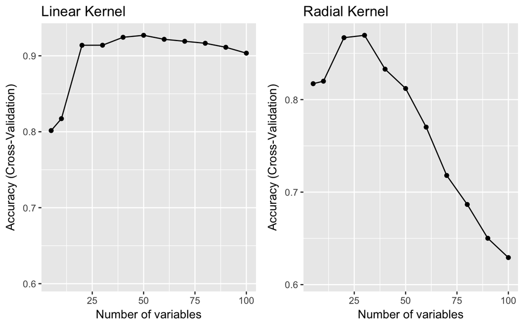

```r
p1 <- qplot(lin.profile$results$Variables,lin.profile$results$Accuracy)+
  xlim(5,100)+geom_line()+
  xlab("Number of variables")+
  ylab("Accuracy (Cross-Validation)")+
  ggtitle("Linear Kernel")
p2 <- qplot(rf.profile$results$Variables,rf.profile$results$Accuracy)+
  xlim(5,100)+geom_line()+
  xlab("Number of variables")+
  ylab("Accuracy (Cross-Validation)")+
  ggtitle("Radial Kernel")
multiplot(p1,p2,cols=2)
```

### Parameter selection

We set the cross validation as our resampling method in the training process and its number of folds.

```r
train.control <- trainControl(method='cv', number=3)
```

#### Linear Kernel

And now we can use our previously defined function. First, we try with the linear Kernel.

```r
tune.grid <- expand.grid(list(C=c(0.1,0.25,0.5,1,10,100)))
svmFitLin <- fitting("svmLinear",tune.grid,predictors(lin.profile))
```

```
Support Vector Machines with Linear Kernel

383 samples
 50 predictor
  2 classes: 'CESC', 'UCEC'

Pre-processing: centered (50), scaled (50)
Resampling: Cross-Validated (3 fold)
Summary of sample sizes: 256, 255, 255
Resampling results across tuning parameters:

  C       Accuracy   Kappa
    0.10  0.9137959  0.8197204
    0.25  0.9033383  0.7965602
    0.50  0.8850681  0.7567630
    1.00  0.8719652  0.7286475
   10.00  0.8588009  0.7013432
  100.00  0.8535925  0.6905579

Accuracy was used to select the optimal model using  the largest value.
The final value used for the model was C = 0.1.
Confusion Matrix and Statistics

          Reference
Prediction CESC UCEC
      CESC   71    2
      UCEC    6   48

               Accuracy : 0.937
                 95% CI : (0.8797, 0.9724)
    No Information Rate : 0.6063
    P-Value [Acc > NIR] : <2e-16

                  Kappa : 0.8699
 Mcnemar's Test P-Value : 0.2888

            Sensitivity : 0.9221
            Specificity : 0.9600
         Pos Pred Value : 0.9726
         Neg Pred Value : 0.8889
             Prevalence : 0.6063
         Detection Rate : 0.5591
   Detection Prevalence : 0.5748
      Balanced Accuracy : 0.9410

       'Positive' Class : CESC
```

#### Non-linear Kernel

And now we try with the Radial Kernel.

```r
tune.grid <- expand.grid(list(sigma=c(0.1,0.25,0.5,1,10,100),
                              C=c(0.1,0.25,0.5,1,10,100)))
svmFitRad <- fitting("svmRadial",tune.grid,predictors(rf.profile))
```

```
Support Vector Machines with Radial Basis Function Kernel

383 samples
 30 predictor
  2 classes: 'CESC', 'UCEC'

Pre-processing: centered (30), scaled (30)
Resampling: Cross-Validated (3 fold)
Summary of sample sizes: 256, 255, 255
Resampling results across tuning parameters:

  sigma   C       Accuracy   Kappa
    0.10    0.10  0.8825664  0.76666418
    0.10    0.25  0.9112943  0.82180189
    0.10    0.50  0.9165026  0.83153927
    0.10    1.00  0.9269603  0.85201769
    0.10   10.00  0.9347728  0.86674704
    0.10  100.00  0.9347728  0.86674704
    0.25    0.10  0.8172572  0.64612560
    0.25    0.25  0.8433809  0.69351204
    0.25    0.50  0.8564427  0.71710666
    0.25    1.00  0.8851501  0.77095647
    0.25   10.00  0.8956488  0.79100960
    0.25  100.00  0.8956488  0.79100960
    0.50    0.10  0.6161622  0.03331339
    0.50    0.25  0.7780922  0.57697898
    0.50    0.50  0.8068200  0.62744582
    0.50    1.00  0.8433809  0.69351204
    0.50   10.00  0.8407562  0.68735709
    0.50  100.00  0.8407562  0.68735709
    1.00    0.10  0.6057456  0.00000000
    1.00    0.25  0.6057456  0.00000000
    1.00    0.50  0.8016732  0.61919264
    1.00    1.00  0.8094242  0.63206728
    1.00   10.00  0.8172777  0.64619657
    1.00  100.00  0.8172777  0.64619657
   10.00    0.10  0.6057456  0.00000000
   10.00    0.25  0.6057456  0.00000000
   10.00    0.50  0.6057456  0.00000000
   10.00    1.00  0.6057456  0.00000000
```

[output cut: 21 more lines]

```
    P-Value [Acc > NIR] : < 2e-16

                  Kappa : 0.8717
 Mcnemar's Test P-Value : 0.01333

            Sensitivity : 0.8961
            Specificity : 1.0000
         Pos Pred Value : 1.0000
         Neg Pred Value : 0.8621
             Prevalence : 0.6063
         Detection Rate : 0.5433
   Detection Prevalence : 0.5433
      Balanced Accuracy : 0.9481

       'Positive' Class : CESC
```

Also we can visualize the most relevant features based on variable importance.

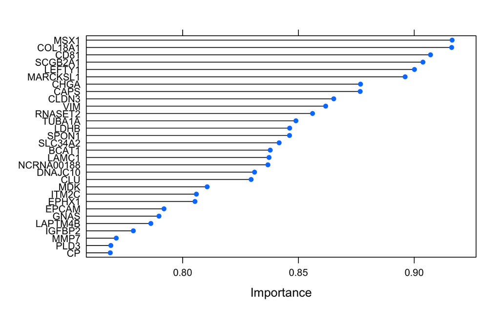

```r
plot(varImp(svmFitRad, scale = FALSE))
```

### Dimensionality reduction: t-SNE

Now we perform dimensionality reduction through the t-SNE algorithm. We use the **Rtsne** package and set the dimension of the embedded space to be 2.

We need to modify slightly our fitting function in order to be performed over our embedded space.

```r
fitting_embedd <- function(method, tune.grid) {
  set.seed(108783)
  fit <- train(x=(embedd[inTrain,]), y=train$label,
                method = method, tuneGrid = tune.grid,
                trControl = train.control, scaled = FALSE, preProcess = c("center","scale"))

  preds <- predict(fit, newdata =  embedd[-inTrain,])
  cm <- confusionMatrix(preds,test$label)
  print(fit)
  print(cm)
  acc_labels <- if_else(preds != test$label, "Incorrect", "Correct")
  return(list(fit,acc_labels))
  }
```

Now we run t-SNE algorithm and get the low dimensional representation of our data.

```r
tsne <- Rtsne(as.matrix(df %>% select(-label)), dims = 2, perplexity=30, verbose=TRUE, max_iter = 1000)
```

```
Read the 510 x 50 data matrix successfully!
Using no_dims = 2, perplexity = 30.000000, and theta = 0.500000
Computing input similarities...
Normalizing input...
Building tree...
 - point 0 of 510
Done in 0.08 seconds (sparsity = 0.272526)!
Learning embedding...
Iteration 50: error is 57.473186 (50 iterations in 0.30 seconds)
Iteration 100: error is 56.830127 (50 iterations in 0.22 seconds)
Iteration 150: error is 56.863115 (50 iterations in 0.22 seconds)
Iteration 200: error is 56.829711 (50 iterations in 0.21 seconds)
Iteration 250: error is 56.885925 (50 iterations in 0.22 seconds)
Iteration 300: error is 0.919037 (50 iterations in 0.22 seconds)
Iteration 350: error is 0.861936 (50 iterations in 0.21 seconds)
Iteration 400: error is 0.849529 (50 iterations in 0.21 seconds)
Iteration 450: error is 0.844176 (50 iterations in 0.20 seconds)
Iteration 500: error is 0.841713 (50 iterations in 0.27 seconds)
Iteration 550: error is 0.840936 (50 iterations in 0.20 seconds)
Iteration 600: error is 0.839823 (50 iterations in 0.21 seconds)
Iteration 650: error is 0.839271 (50 iterations in 0.20 seconds)
Iteration 700: error is 0.838066 (50 iterations in 0.22 seconds)
Iteration 750: error is 0.837843 (50 iterations in 0.21 seconds)
Iteration 800: error is 0.837185 (50 iterations in 0.20 seconds)
Iteration 850: error is 0.836979 (50 iterations in 0.19 seconds)
Iteration 900: error is 0.837402 (50 iterations in 0.21 seconds)
Iteration 950: error is 0.836095 (50 iterations in 0.21 seconds)
Iteration 1000: error is 0.835838 (50 iterations in 0.21 seconds)
Fitting performed in 4.35 seconds.
```

```r
embedd <- data.frame(tsne$Y)
```

Now that we have performed the embedding, we can call our previously defined function. As before, we try with both the linear Kernel and the non-linear Kernel.

#### Linear Kernel

```r
tune.grid <- expand.grid(list(C=c(0.1,0.25,0.5,1,10,100)))
output <- fitting_embedd("svmLinear",tune.grid)
```

```
Support Vector Machines with Linear Kernel

383 samples
  2 predictor
  2 classes: 'CESC', 'UCEC'

Pre-processing: centered (2), scaled (2)
Resampling: Cross-Validated (3 fold)
Summary of sample sizes: 256, 255, 255
Resampling results across tuning parameters:

  C       Accuracy   Kappa
    0.10  0.9034818  0.8038562
    0.25  0.9008161  0.7971311
    0.50  0.9034408  0.8023822
    1.00  0.9008161  0.7966929
   10.00  0.8955873  0.7854264
  100.00  0.8929831  0.7797884

Accuracy was used to select the optimal model using  the largest value.
The final value used for the model was C = 0.1.
Confusion Matrix and Statistics

          Reference
Prediction CESC UCEC
      CESC   69    1
      UCEC    8   49

               Accuracy : 0.9291
                 95% CI : (0.8697, 0.9671)
    No Information Rate : 0.6063
    P-Value [Acc > NIR] : <2e-16

                  Kappa : 0.8551
 Mcnemar's Test P-Value : 0.0455

            Sensitivity : 0.8961
            Specificity : 0.9800
         Pos Pred Value : 0.9857
         Neg Pred Value : 0.8596
             Prevalence : 0.6063
         Detection Rate : 0.5433
   Detection Prevalence : 0.5512
      Balanced Accuracy : 0.9381

       'Positive' Class : CESC
```

```r
svmFitLin_tsne <- output[[1]]
acc_labels_linear <- output[[2]]
rm(output)
```

```r
dat.grid <- expand.grid(X1=seq(-20,20,0.1), X2=seq(-15,15,0.1))
dat.grid$preds_linear <- predict(svmFitLin_tsne, newdata = dat.grid[,1:2])
plot_linear <- ggplot(dat.grid, aes(x=X1, y=X2))+geom_point(size=1, alpha=0.2, aes(colour=preds_linear)) +
  geom_point(data=embedd[-inTrain,], aes(colour=factor(test$label),size = factor(acc_labels_linear))) +
  xlim(-20,20) + ylim(-15,15) +
  theme(legend.title=element_blank()) +
  xlab("1st dimension") + ylab("2nd dimension")
```

```r
#plot_linear
```

#### Non-linear Kernel

```r
tune.grid <- expand.grid(list(sigma=c(0.1,0.25,0.5,1,10,100),
                              C=c(0.1,0.25,0.5,1,10,100)))
output <- fitting_embedd("svmRadial",tune.grid)
```

```
Support Vector Machines with Radial Basis Function Kernel

383 samples
  2 predictor
  2 classes: 'CESC', 'UCEC'

Pre-processing: centered (2), scaled (2)
Resampling: Cross-Validated (3 fold)
Summary of sample sizes: 256, 255, 255
Resampling results across tuning parameters:

  sigma   C       Accuracy   Kappa
    0.10    0.10  0.9008981  0.7982636
    0.10    0.25  0.8930856  0.7843180
    0.10    0.50  0.8904610  0.7782754
    0.10    1.00  0.8982735  0.7938470
    0.10   10.00  0.8982119  0.7915344
    0.10  100.00  0.9008161  0.7966079
    0.25    0.10  0.9008981  0.7992468
    0.25    0.25  0.8956898  0.7892626
    0.25    0.50  0.8982735  0.7932248
    0.25    1.00  0.8930036  0.7820473
    0.25   10.00  0.9008161  0.7966079
    0.25  100.00  0.8955668  0.7862141
    0.50    0.10  0.8930856  0.7843180
    0.50    0.25  0.8930651  0.7837728
    0.50    0.50  0.8982530  0.7927119
    0.50    1.00  0.8956078  0.7870860
    0.50   10.00  0.8955668  0.7862118
    0.50  100.00  0.8825049  0.7591565
    1.00    0.10  0.9008981  0.7992072
    1.00    0.25  0.8982324  0.7921250
    1.00    0.50  0.8956078  0.7864963
    1.00    1.00  0.8955873  0.7868762
    1.00   10.00  0.8877338  0.7704373
    1.00  100.00  0.8747334  0.7403605
   10.00    0.10  0.6867003  0.2505817
   10.00    0.25  0.8799623  0.7483093
   10.00    0.50  0.8825664  0.7558065
   10.00    1.00  0.8825254  0.7543939
```

[output cut: 21 more lines]

```
    P-Value [Acc > NIR] : <2e-16

                  Kappa : 0.8708
 Mcnemar's Test P-Value : 0.0771

            Sensitivity : 0.9091
            Specificity : 0.9800
         Pos Pred Value : 0.9859
         Neg Pred Value : 0.8750
             Prevalence : 0.6063
         Detection Rate : 0.5512
   Detection Prevalence : 0.5591
      Balanced Accuracy : 0.9445

       'Positive' Class : CESC
```

```r
svmFitRad_tsne <- output[[1]]
acc_labels_radial <- output[[2]]
rm(output)
```

```r
#dat.grid <- expand.grid(X1=seq(-20,20,0.1), X2=seq(-15,15,0.1))
dat.grid$preds_radial <- predict(svmFitRad_tsne, newdata = dat.grid[,1:2])
plot_radial <- ggplot(dat.grid, aes(x=X1, y=X2))+geom_point(size=1, alpha=0.2, aes(colour=preds_radial)) +
  geom_point(data=embedd[-inTrain,], aes(colour=factor(test$label),size = factor(acc_labels_radial))) +
  xlim(-20,20) + ylim(-15,15) +
  theme(legend.title=element_blank()) +
  xlab("1st dimension") + ylab("2nd dimension")
```

```r
#plot_radial
```

## 3.3.2 - Logistic regression

### Feature selection: regularized model

Now we perform L1 regularized logistic regression with cross validation using the *cv.glmnet* function from **glmnet** package in order to select the best predictor variables so we can use them later in a standard logistic regression model. We select the variables based on the largest value of lambda such that error is within one standard error of the minimum.

```r
set.seed(108783)
lasso <- cv.glmnet(x=as.matrix(train %>% select(-label)),
                   y = as.numeric(if_else(train$label == "CESC",1,0)),
                   family="binomial",
                   nfolds = 3, type.measure = "class")
lassovars <- colnames(train)[which(coef(lasso, s = "lambda.1se") != 0)]
print(lassovars)
```

```
 [1] "A1BG"    "ACTR3C"  "ADORA3"  "CHST11"  "DNAJC3"  "FBXO17"  "GJB4"    "KPNA1"   "PAX9"    "PRIM2"   "SNTA1"   "TLE2"
[13] "VPS39"   "WDR77"   "ZNF280C" "ZNF440"  "ZNF611"  "ZSCAN1"
```

### Regularization parameter selection

We can visualize the feature selection process as a function of the regularization parameter.

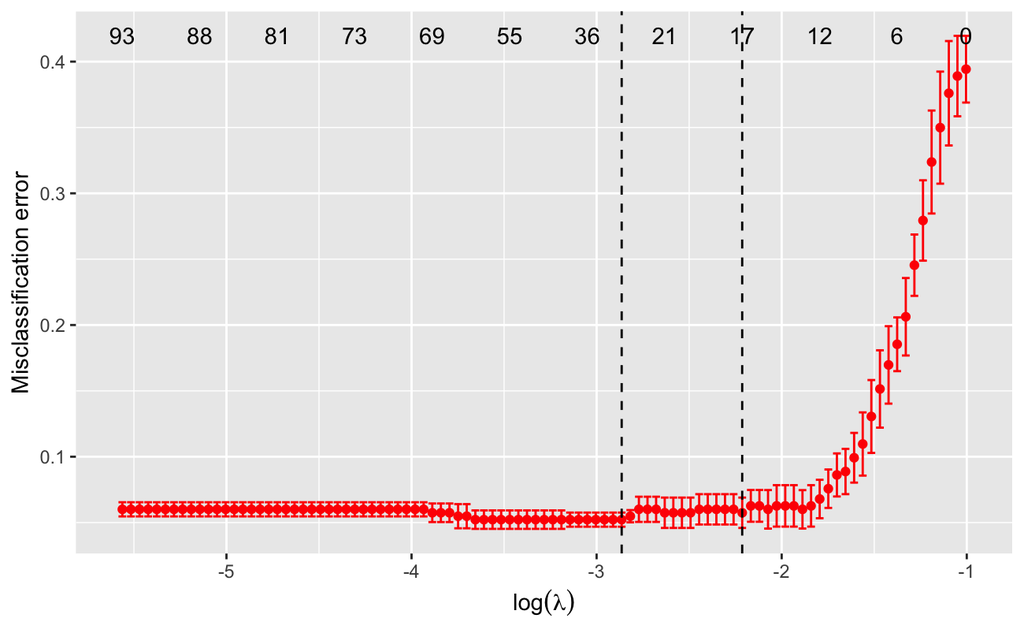

```r
autoplot(lasso, colour = 'red') + xlab(expression(log(lambda))) + ylab("Misclassification error")
```

### Non-regularized model

Once we have chosen the best predictor variables, we can use them to fit a standard logistic regression model. We define a function to perform some preprocessing, fit the model and predict classes in the test dataset. We use a simple cutoff point of 0.5 to assign the classes based on the probabilities.

```r
fitting_glm<-function(varsmodel) {
  pp <- preProcess(train %>% select(one_of(varsmodel)), method=c("center","scale"))
  xaux <- predict(pp,train %>% select(one_of(varsmodel)))
  yaux <- as.numeric(if_else(train$label == "CESC",1,0))
  dfaux <- cbind(xaux,yaux)
  rm(xaux,yaux)

  model <- glm(as.numeric(yaux) ~ ., data = dfaux, family=binomial)

  xauxt <- predict(pp,test %>% select(one_of(varsmodel)))
  yauxt <- as.numeric(if_else(test$label == "CESC",1,0))
  dfauxt <- cbind(xauxt,yauxt)
  rm(xauxt,yauxt)
  preds_model <- predict.glm(model,newdata=dfauxt,type="response")
  preds_model <- if_else(preds_model >= 0.5, "CESC", "UCEC")

  cm <- confusionMatrix(preds_model,test$label)
  print(summary(model))
  print(cm)
  return(model)
}
```

Now we apply our previously defined function and see how it performs.

```r
full_model <- fitting_glm(lassovars)
```

```
glm.fit: fitted probabilities numerically 0 or 1 occurred
```

```
Call:
glm(formula = as.numeric(yaux) ~ ., family = binomial, data = dfaux)

Deviance Residuals:
    Min       1Q   Median       3Q      Max
-3.5468  -0.3410   0.0209   0.2583   3.1839

Coefficients:
            Estimate Std. Error z value Pr(>|z|)
(Intercept)  2.07831    0.44662   4.653 3.26e-06 ***
A1BG        -0.40191    0.29353  -1.369  0.17092
ACTR3C      -0.25624    0.19860  -1.290  0.19697
ADORA3       0.15673    0.18469   0.849  0.39610
CHST11       0.06563    0.17837   0.368  0.71293
DNAJC3      -0.33237    0.20110  -1.653  0.09838 .
FBXO17      -0.21861    0.16521  -1.323  0.18577
GJB4         3.20780    0.75492   4.249 2.15e-05 ***
KPNA1        1.33072    0.34018   3.912 9.16e-05 ***
PAX9         2.81327    1.09040   2.580  0.00988 **
PRIM2        0.51638    0.20320   2.541  0.01104 *
SNTA1       -0.15299    0.31008  -0.493  0.62174
TLE2         0.20665    0.18859   1.096  0.27317
VPS39       -0.16980    0.21376  -0.794  0.42700
WDR77       -0.63777    0.30835  -2.068  0.03861 *
ZNF280C     -0.61850    0.21416  -2.888  0.00388 **
ZNF440      -0.28194    0.26253  -1.074  0.28285
ZNF611      -0.18313    0.21919  -0.835  0.40344
ZSCAN1      -0.77591    0.36669  -2.116  0.03435 *
---
Signif. codes:  0 '***' 0.001 '**' 0.01 '*' 0.05 '.' 0.1 ' ' 1

(Dispersion parameter for binomial family taken to be 1)

    Null deviance: 513.69  on 382  degrees of freedom
Residual deviance: 191.80  on 364  degrees of freedom
AIC: 229.8

Number of Fisher Scoring iterations: 8

Confusion Matrix and Statistics
```

[output cut: 9 more lines]

```
    P-Value [Acc > NIR] : 3.61e-14

                  Kappa : 0.8048
 Mcnemar's Test P-Value : 0.3865

            Sensitivity : 0.8961
            Specificity : 0.9200
         Pos Pred Value : 0.9452
         Neg Pred Value : 0.8519
             Prevalence : 0.6063
         Detection Rate : 0.5433
   Detection Prevalence : 0.5748
      Balanced Accuracy : 0.9081

       'Positive' Class : CESC
```

We observe that not all variables are statistically significant according to this specification. We can keep the variables that in fact are significant.

```r
sub_lassovars <- names(which((summary(full_model)$coeff[-1,4] < 0.05)))
print(sub_lassovars)
```

```
[1] "GJB4"    "KPNA1"   "PAX9"    "PRIM2"   "WDR77"   "ZNF280C" "ZSCAN1"
```

And finally we apply our previously defined function over this subset of variables to get a parsimonious model and see how it performs.

```r
reduced_model <- fitting_glm(sub_lassovars)
```

```
glm.fit: fitted probabilities numerically 0 or 1 occurred
```

```
Call:
glm(formula = as.numeric(yaux) ~ ., family = binomial, data = dfaux)

Deviance Residuals:
    Min       1Q   Median       3Q      Max
-3.6204  -0.3915   0.0219   0.2958   2.8883

Coefficients:
            Estimate Std. Error z value Pr(>|z|)
(Intercept)   2.0501     0.4169   4.917 8.79e-07 ***
GJB4          3.2704     0.6734   4.856 1.20e-06 ***
KPNA1         1.2157     0.2929   4.150 3.32e-05 ***
PAX9          2.8717     1.0939   2.625  0.00866 **
PRIM2         0.5389     0.1721   3.132  0.00174 **
WDR77        -0.5747     0.2679  -2.145  0.03196 *
ZNF280C      -0.5624     0.1901  -2.957  0.00310 **
ZSCAN1       -0.9378     0.3973  -2.360  0.01826 *
---
Signif. codes:  0 '***' 0.001 '**' 0.01 '*' 0.05 '.' 0.1 ' ' 1

(Dispersion parameter for binomial family taken to be 1)

    Null deviance: 513.69  on 382  degrees of freedom
Residual deviance: 205.37  on 375  degrees of freedom
AIC: 221.37

Number of Fisher Scoring iterations: 7

Confusion Matrix and Statistics

          Reference
Prediction CESC UCEC
      CESC   69    5
      UCEC    8   45

               Accuracy : 0.8976
                 95% CI : (0.8313, 0.9444)
    No Information Rate : 0.6063
    P-Value [Acc > NIR] : 2.11e-13

                  Kappa : 0.7878
 Mcnemar's Test P-Value : 0.5791

            Sensitivity : 0.8961
            Specificity : 0.9000
         Pos Pred Value : 0.9324
         Neg Pred Value : 0.8491
             Prevalence : 0.6063
         Detection Rate : 0.5433
   Detection Prevalence : 0.5827
      Balanced Accuracy : 0.8981

       'Positive' Class : CESC
```

Additionally, if we would like to give some interpretation to the variables used in the SVM model with the non-linear Kernel, we can see how a logistic regression model perform using this set of variables.

```r
topvars_model <- fitting_glm(predictors(rf.profile))
```

```
glm.fit: fitted probabilities numerically 0 or 1 occurred
```

```
Call:
glm(formula = as.numeric(yaux) ~ ., family = binomial, data = dfaux)

Deviance Residuals:
     Min        1Q    Median        3Q       Max
-2.10118  -0.00458   0.01683   0.05952   3.11592

Coefficients:
            Estimate Std. Error z value Pr(>|z|)
(Intercept) -0.36587    0.62726  -0.583 0.559709
MSX1        -2.36141    1.59950  -1.476 0.139852
COL18A1      0.45149    0.54346   0.831 0.406099
CD81        -0.10544    0.60020  -0.176 0.860544
SCGB2A1     -0.91607    1.35126  -0.678 0.497810
LEFTY1      -0.72674    0.62039  -1.171 0.241427
MARCKSL1    -1.87748    0.86995  -2.158 0.030917 *
CAPS        -1.12194    1.45936  -0.769 0.442017
CHGA         0.16014    0.83338   0.192 0.847617
CLDN3       -1.20232    0.64547  -1.863 0.062502 .
VIM         -0.39851    0.59073  -0.675 0.499925
RNASET2     -1.13029    0.86270  -1.310 0.190137
TUBA1A      -0.05600    0.31958  -0.175 0.860904
LDHB        -1.13309    0.48963  -2.314 0.020659 *
SPON1       -1.20170    1.04681  -1.148 0.250987
SLC34A2      0.04134    0.38518   0.107 0.914525
BCAT1       -0.30561    0.43119  -0.709 0.478470
LAMC1       -3.84656    1.31995  -2.914 0.003566 **
NCRNA00188  -1.21189    0.59333  -2.043 0.041102 *
DNAJC10      0.08784    1.54952   0.057 0.954791
CLU         -2.01807    0.73677  -2.739 0.006161 **
MDK         -0.68831    0.60801  -1.132 0.257607
ITM2C        0.96576    0.63033   1.532 0.125482
EPHX1       -1.16037    0.70122  -1.655 0.097967 .
EPCAM        1.05631    0.71377   1.480 0.138902
GNAS        -0.48798    0.43336  -1.126 0.260156
LAPTM4B      1.70831    0.49573   3.446 0.000569 ***
IGFBP2       0.34369    0.67537   0.509 0.610823
MMP7        -1.11889    0.58160  -1.924 0.054377 .
PLD3        -0.74350    0.41547  -1.790 0.073524 .
CP          -0.32260    0.53468  -0.603 0.546278
```

[output cut: 21 more lines]

```
    P-Value [Acc > NIR] : 2.11e-13

                  Kappa : 0.7863
 Mcnemar's Test P-Value : 1

            Sensitivity : 0.9091
            Specificity : 0.8800
         Pos Pred Value : 0.9211
         Neg Pred Value : 0.8627
             Prevalence : 0.6063
         Detection Rate : 0.5512
   Detection Prevalence : 0.5984
      Balanced Accuracy : 0.8945

       'Positive' Class : CESC
```

And we can see which one of these variables are in fact significant according to this specification. Also, we can give some interpretation based on the sign of the parameters.